# Homework 1: Basics of machine learning and feedforward neural networks

## This assignment includes:

## 1. Mathematical questions (20 points)

## 2. Coding in Python (pytorch): train softmax classifiers on MNIST (80 points)

2.0 Install and configure: python ([Anaconda platform](https://docs.anaconda.com/anaconda/install/) recommended), [Jupyter Notebook](https://jupyter.org/install) and [pytorch](https://pytorch.org/get-started/)

2.1 Read provided code (with pytorch)

2.2 Complete the code of mini-batch SGD for linear softmax classifier

2.3 Record and plot results to show the loss and accuracy convergence (against #epoch)

2.4 Complete the code of multilayer feedforward network and train the nonlinear models

## Submission:

- Convert the ipynb file to html file (**save the execution outputs**)
- Upload both your ipynb and html files to blackboard.
- Deadline: Feb 28, 11:59:59 PM, Pacific time.

## Hints for the coding part:

1. If you are more comfortable to use other libraries such as Keras and TensorFlow, you can change the code accordingly.
2. Implement your code using the computation of vectors and matrics, rather than the for-loop to compute each element in vectors and matrics.
3. Plots should be clear and easy to read.

# 1. Mathematical questions:

## 1.1. Equivalence between: MLE using Bernoulli distribution and logistic regression

Read Section 5.5, 6.2.2.2, 6.2.2.3 in [Deep Learning Book](https://www.deeplearningbook.org/). Explain why logistic regression is equivalent to Maximum likelihood estimation.

Optional reading material that may help: [this lecture notes](https://www.stat.cmu.edu/~cshalizi/uADA/12/lectures/ch12.pdf), Section 12.2.1 and 12.2.2.

```python
# 1.1
#   Logistic regression assumes that the data obeys the Bernoulli distribution.
# Through the method of maximum likelihood function, gradient descent is used to solve
# the parameters to achieve the purpose of binary classification of the data.
#   The maximum likelihood estimation is to use the known results to reverse the parameters
# that have the maximum probability to cause the results.
#   Logistic regression is a kind of supervised learning with training labels (known results),
# which can be used to derive the result parameters. By obtaining this parameter, the model can accurately predict unknown data.
#   Therefore, logistic regression is equivalent to Maximum likelihood estimation.
```

## 1.2. Determine the convexity of a function

1.2.1. Suppose we have a functioin $f({\bf x}) = \log( \sum_{i=1}^n \exp(x_i) )$, where ${\bf x} \in \mathbb R^d$ and $x_i$ is the $i$-th element of ${\bf x}$ (so {\bf x} is a vector and $x_i$ is a scalar).

Question: is $f({\bf x})$ a convex function?

Answer:

1.2.2. We introduced logistic regression for binary classification. Its objective function is \begin{align*} f({\bf w}) = \frac{1}{n} \sum_{i=1}^n \log( 1 + \exp( - y_i {\bf w}^\top {\bf x}_i ) ) + \frac{\lambda}{2} \| {\bf w} \|^2 , \end{align*} where ${\bf x}_i \in \mathbb R^d, y_i \in \{ -1, +1 \}$.

Question: is the above objective function convex or not?

Answer:

**Example:** We can use the second order derivatives $\nabla^2 f$ to see whether a function $f$ is convex: if the second order derivatives are positive definite (when $f$ has vector inputs), or positive number (when $f$ has scalar inputs). Suppose $f({\bf x}) = 1/2 * {\bf x}^\top {\bf x}$. Then we compute its first order and second order derivative: \begin{align*} & \nabla f({\bf x}) = {\bf x} \\ & \nabla^2 f({\bf x}) = {\bf 1} , \end{align*} where ${\bf 1}$ is positive definite (why?).

Hint: you can find how to compute derivatives of vectors/matrics in Section 2 in [The Matrix Cookbook](https://www.math.uwaterloo.ca/~hwolkowi/matrixcookbook.pdf)

```python
# 1.2.1
##   No. If the second derivative of the function is greater than 0, the function is convex.
##   The second derivative of f(x) is 0. Si it's not convex funtion.

# 1.2.2
##   It's convex. The first derivative of f(w) is (λ/2)∥w∥^2 = λw; The second derivative of f(w) is λ. λ is positive. So its convex function.
```

# 2. Coding

## 2.1. (Read and run) Load MNIST dataset using pytorch and scale features

```python
import matplotlib.pyplot as plt
import numpy
from torchvision import datasets, transforms

train_set = datasets.MNIST('./data', train=True, download=True)
test_set = datasets.MNIST('./data', train=False, download=True)

x_train = train_set.data.numpy()
x_train = x_train.reshape(len(x_train),-1)
x_test = test_set.data.numpy()
x_test = x_test.reshape(len(x_test),-1)

y_train = train_set.targets.numpy()
y_test = test_set.targets.numpy()

print('Shape of x_train: ' + str(x_train.shape))
print('Shape of x_test: ' + str(x_test.shape))

print('Shape of y_train: ' + str(y_train.shape))
print('Shape of y_test: ' + str(y_test.shape))

# calculate mu and sig using the training set
d = x_train.shape[1]
mu = numpy.mean(x_train, axis=0).reshape(1, d)
sig = numpy.std(x_train, axis=0).reshape(1, d)

# transform the training features
x_train = (x_train - mu) / (sig + 1E-6)

# transform the test features
x_test = (x_test - mu) / (sig + 1E-6)
```

```
Shape of x_train: (60000, 784)
Shape of x_test: (10000, 784)
Shape of y_train: (60000,)
Shape of y_test: (10000,)
```

## 2.2. (Read and run) Visualize a random image

```
Its label is
4
```

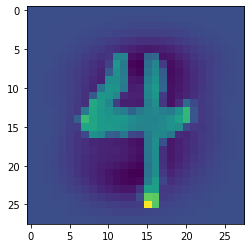

```python
d = x_train.shape[0]
random_index = numpy.random.randint(d, size=1)[0]
plt.imshow(x_train[random_index].reshape(28,28))
print('Its label is')
print(y_train[random_index])
```

## 2.3. (Read and run) Define softmax function and cross entropy loss

```python
def softmax(z):
    """implement the softmax functions
    input: numpy ndarray
    output: numpy ndarray
    """
    exp_list = numpy.exp(z)
    result = 1/sum(exp_list) * exp_list
    result = result.reshape((len(z),1))
    assert (result.shape == (len(z),1))
    return result

def neg_log_loss(pred, label):
    """implement the negative log loss"""
    loss = -numpy.log(pred[int(label)])
    return loss
```

## 2.4 (Read and run) Functions for implementing linear softmax classifier

```python
import os
import sys
import json

root = os.path.abspath('.')
root += '/configs/'

def loadConfig(name):
    """ Read a configuration file as a dictionary"""
    full_path = root + name
    json_file = open(full_path, 'r')
    cfg = json.load(json_file)
    json_file.close()
    return cfg

def initialize(num_inputs,num_classes):
    """initialize the parameters"""
    # num_inputs = 28*28 = 784
    # num_classes = 10
    w = numpy.zeros((num_classes, num_inputs)) # (10*784)
    b = numpy.zeros((num_classes, 1)) # (10*1)

    param = {
        'w' : w, # (10*784)
        'b' : b  # (10*1)
    }
    return param

def eval(param, hyp, x_data, y_data):
    """ implement the evaluation function
    input: param -- parameters dictionary (w, b)
           hyp -- hyper-parameter: we use hyp['lambda'] to compute regularization
           x_data -- x_train or x_test (size, 784)
           y_data -- y_train or y_test (size,)
    output: loss and accuracy
    """

    reg_lambda = hyp['lambda']

    # w: (10*784), x: (10000*784), y:(10000,)
    loss_list = []
    w = param['w'].transpose()
    b = param['b'].transpose()
    dist = numpy.array([numpy.squeeze(softmax(numpy.matmul(x_data[i], w))) for i in range(len(y_data))])

    result = numpy.argmax(dist,axis=1)
    accuracy = sum(result == y_data)/float(len(y_data))

    loss_list = [neg_log_loss(dist[i],y_data[i]) for i in range(len(y_data))]
    loss = sum(loss_list) / len(loss_list) + reg_lambda/2 * numpy.sum(w * w) + reg_lambda/2 * numpy.sum(b * b)
    return loss, accuracy

def train(param, hyp, x_train, y_train, x_test, y_test,cfg_idx):
    """ implement the train function
    input: param -- parameters dictionary (w, b)
           hyp -- hyperparameters dictionary
           x_train -- (60000, 784)
           y_train -- (60000,)
           x_test -- x_test (10000, 784)
           y_test -- y_test (10000,)
    output: train_loss_list, train_acc_list, test_loss_list, test_acc_list
           Four lists contain the epoch-wise loss function on training data, accuracy on training data, loss function on testing data, accuracy on testing data, respectively
    """
    num_epoches = hyp['num_epoches']
    batch_size = hyp['batch_size']
    learning_rate = hyp['learning_rate']
    mu = hyp['mu']
    reg_lambda = hyp['lambda']
    train_loss_list, train_acc_list, test_loss_list, test_acc_list = [],[],[],[]
    if bool(hyp['momentum']) == True:
        w_velocity = numpy.zeros(param['w'].shape)
        b_velocity = numpy.zeros(param['b'].shape)

    for epoch in range(num_epoches):

        # select the random sequence of training set
        rand_indices = numpy.random.choice(x_train.shape[0],x_train.shape[0],replace=False)
        num_batch = int(x_train.shape[0]/batch_size)

        if bool(hyp['learning_decay']) == True:
            try:
                if test_acc_list[-1] - test_acc_list[-2] < 0.001:
                    learning_rate *= hyp['decay_factor']
            except:
                pass

            message = 'learning rate: %.8f' % learning_rate
            print(message)
            logging.info(message)

        # for each batch of train data
        for batch in range(num_batch):
            index = rand_indices[batch_size*batch:batch_size*(batch+1)]
            x_batch = x_train[index]
            y_batch = y_train[index]

            # calculate the stochastic gradient w.r.t w and b
            dw, db, batch_loss = mini_batch_gradient(param, x_batch, y_batch, reg_lambda)

            param['w'] -= learning_rate * dw
            param['b'] -= learning_rate * db

            if (batch+1) % 100 == 0:
                message = 'Epoch [%d/%d], Batch [%d/%d], Loss %.4f' % (epoch+1, num_epoches, batch+1, num_batch, batch_loss)
                print(message)

        train_loss, train_acc = eval(param,hyp,x_train,y_train)
        test_loss, test_acc = eval(param,hyp,x_test,y_test)
        train_loss_list.append(train_loss)
        train_acc_list.append(train_acc)
        test_loss_list.append(test_loss)
        test_acc_list.append(test_acc)

        message = 'Epoch %d/%d, Train Loss %.4f, Train Acc %.4f, Test Loss %.4f, Test Acc %.4f' % (epoch+1, num_epoches, train_loss, train_acc, test_loss, test_acc)
        print(message)
        logging.info(message)
    return train_loss_list, train_acc_list, test_loss_list, test_acc_list


def plot(train_loss_list, train_acc_list, test_loss_list, test_acc_list, cfg_idx):
    """store the plots"""
    # epoch_list = list(range(len(loss_list)))
    plt.plot(train_loss_list, '-b', label='train loss')
    plt.plot(test_loss_list, '-r', label='test loss')
    plt.legend()
    plt.ylabel('Loss Function')
    plt.xlabel('Epoch')
    plt.xticks(rotation=60)
    plt.title('Loss Function ~ Epoch')
    plt.savefig('assets/loss_{}.png'.format(cfg_idx))
    plt.show()

    plt.plot(train_acc_list, '-b', label='train acc')
    plt.plot(test_acc_list, '-r', label='test acc')
    plt.legend()
    plt.ylabel('Accuracy')
    plt.xlabel('Epoch')
    plt.xticks(rotation=60)
    plt.title('Accuracy ~ Epoch')
    plt.savefig('assets/accr_{}.png'.format(cfg_idx))
    plt.show()


def main(cfg_idx):
#     cfg_idx = args.config
    cfg_name = 'config_{}.json'.format(cfg_idx)
    hyperpara = loadConfig(cfg_name)

    # setting the random seed
    numpy.random.seed(1024)

    # initialize the parameters
    num_inputs = x_train.shape[1]
    num_classes = len(set(y_train))
    param = initialize(num_inputs,num_classes)

    # train the model
    train_loss_list, train_acc_list, test_loss_list, test_acc_list = train(param,hyperpara,x_train,y_train,x_test,y_test, cfg_idx)

    # plot the loss and accuracy
    plot(train_loss_list, train_acc_list, test_loss_list, test_acc_list, cfg_idx)
```

## 2.5. (To finish) Implementation of mini-batch SGD

```python
def mini_batch_gradient(param, x_batch, y_batch, reg_lambda):
    """implement the function to compute the mini batch gradient
    input: param -- parameters dictionary (w, b)
           x_batch -- a batch of x (size, 784)
           y_batch -- a batch of y (size,)
           reg_lambdba -- regularization parameter
    output:
           dw -- derivative for weight w
           db -- derivative for bias b
           batch_loss -- average loss on the mini-batch samples
    """

    # Your code goes here
    # weight gradient list
    w_grad_list = []
    # bias gradient list
    b_grad_list = []
    # intialize batch loss
    batch_loss = 0
    batch_size = x_batch.shape[0] # 784
    for i in range(batch_size):
        x = x_batch[i].reshape((784, -1)) # 784 lists with 1 element
        y = y_batch[i] # 1 list target
        y_true  = numpy.zeros((10, 1)) # array([[0.],[0.],[0.],[0.],[0.],[0.],[0.], [0.], [0.], [0.]])
        y_true[y][0] = 1 # change the value appear in y in y_true to 1 (each sets 1 '1')
        y_pred = softmax(numpy.matmul(param['w'], x)+param['b'])
#         print("y_pred: ", y_pred)
        loss = neg_log_loss(y_pred, y)
#         print("loss: ", loss)
        batch_loss += loss
#         print("batch_loss: ", batch_loss)
        w_grad = (y_true  - y_pred)
        b_grad = -(y_true - y_pred)
        w_grad = - numpy.matmul(w_grad, x.reshape((1,784)))
        w_grad_list.append(w_grad)
        b_grad_list.append(b_grad)

    dw = reg_lambda/2*sum(w_grad_list)/batch_size
    db = sum(b_grad_list)/batch_size
    return dw, db, batch_loss
```

## 2.6. (Read and run) Train your model using the provided configuration (in *configs/config_sample.json*) untill convergence

```
Epoch [1/10], Batch [100/600], Loss 229.6793
Epoch [1/10], Batch [200/600], Loss 230.4236
Epoch [1/10], Batch [300/600], Loss 230.5765
Epoch [1/10], Batch [400/600], Loss 228.3359
Epoch [1/10], Batch [500/600], Loss 229.6402
Epoch [1/10], Batch [600/600], Loss 230.6491
Epoch [2/10], Batch [100/600], Loss 229.4569
Epoch [2/10], Batch [200/600], Loss 229.8903
Epoch [2/10], Batch [300/600], Loss 229.5062
Epoch [2/10], Batch [400/600], Loss 230.4477
Epoch [2/10], Batch [500/600], Loss 230.5150
Epoch [2/10], Batch [600/600], Loss 230.3073
Epoch [3/10], Batch [100/600], Loss 230.6085
Epoch [3/10], Batch [200/600], Loss 230.9417
Epoch [3/10], Batch [300/600], Loss 229.7757
Epoch [3/10], Batch [400/600], Loss 230.4154
Epoch [3/10], Batch [500/600], Loss 229.7606
Epoch [3/10], Batch [600/600], Loss 229.5230
Epoch [4/10], Batch [100/600], Loss 230.1829
Epoch [4/10], Batch [200/600], Loss 230.3859
Epoch [4/10], Batch [300/600], Loss 230.5232
Epoch [4/10], Batch [400/600], Loss 230.0250
Epoch [4/10], Batch [500/600], Loss 229.1770
Epoch [4/10], Batch [600/600], Loss 230.4592
Epoch [5/10], Batch [100/600], Loss 229.9830
Epoch [5/10], Batch [200/600], Loss 230.2462
Epoch [5/10], Batch [300/600], Loss 230.0398
Epoch [5/10], Batch [400/600], Loss 229.3069
Epoch [5/10], Batch [500/600], Loss 230.2855
Epoch [5/10], Batch [600/600], Loss 230.2975
Epoch [6/10], Batch [100/600], Loss 229.6478
Epoch [6/10], Batch [200/600], Loss 229.8503
Epoch [6/10], Batch [300/600], Loss 229.4317
Epoch [6/10], Batch [400/600], Loss 230.3310
Epoch [6/10], Batch [500/600], Loss 229.8178
Epoch [6/10], Batch [600/600], Loss 230.0739
Epoch [7/10], Batch [100/600], Loss 230.0623
Epoch [7/10], Batch [200/600], Loss 229.5961
Epoch [7/10], Batch [300/600], Loss 230.4887
Epoch [7/10], Batch [400/600], Loss 230.7973
Epoch [7/10], Batch [500/600], Loss 230.0995
Epoch [7/10], Batch [600/600], Loss 230.2738
Epoch [8/10], Batch [100/600], Loss 231.1037
Epoch [8/10], Batch [200/600], Loss 229.5075
Epoch [8/10], Batch [300/600], Loss 230.4960
Epoch [8/10], Batch [400/600], Loss 230.4513
Epoch [8/10], Batch [500/600], Loss 230.7509
Epoch [8/10], Batch [600/600], Loss 231.0986
Epoch [9/10], Batch [100/600], Loss 229.5084
Epoch [9/10], Batch [200/600], Loss 230.2219
Epoch [9/10], Batch [300/600], Loss 229.3077
Epoch [9/10], Batch [400/600], Loss 230.3512
Epoch [9/10], Batch [500/600], Loss 229.7280
Epoch [9/10], Batch [600/600], Loss 229.5274
Epoch [10/10], Batch [100/600], Loss 231.3016
Epoch [10/10], Batch [200/600], Loss 230.1187
Epoch [10/10], Batch [300/600], Loss 231.6432
Epoch [10/10], Batch [400/600], Loss 229.8982
Epoch [10/10], Batch [500/600], Loss 230.1360
Epoch [10/10], Batch [600/600], Loss 230.4347
```

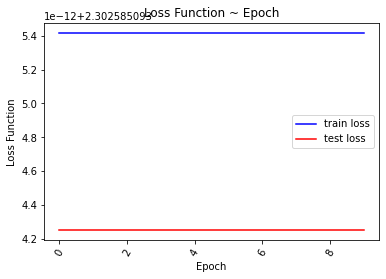

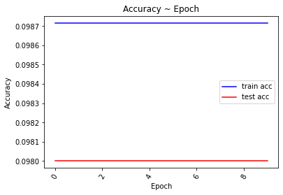

```python
if __name__ == "__main__":

    cfg_idx = 'sample'

    import logging
    logging.basicConfig(filename="./logs/{}.log".format(cfg_idx), filemode="w", format="%(message)s", level=logging.DEBUG)

    main(cfg_idx)
```